# ENTREGA FINAL

ADCPS

2023-05-25

# **Factores que influyen en la baja empleabilidad femenina a nivel mundial en el 2019**

```r
library(rmdformats)
```

## **A. Objetivo del reporte:**

El objetivo del trabajo fue investigar los factores que influyen en la baja empleabilidad femenina a nivel mundial en el año 2019. Sabemos que esta situación en términos generales, indica una realidad dispar o desigualdad en las oportunidades laborales entre ambos géneros y aborda la situación en la que las mujeres enfrentan dificultades para obtener y mantener empleos remunerados.

Para poder lograrlo, se utilizará la técnica de regresión lineal múltiple o Gaussiana. Esta técnica fue elegida debido a su capacidad para analizar múltiples variables independientes y su relación central con una variable dependiente, en este caso, la empleabilidad femenina. El estudio se enfocó en investigar aspectos como la discriminación de género, las barreras educativas, la falta de oportunidades laborales, los estereotipos de género, violencia y otros factores socioeconómicos que pudieran afectar negativamente la baja empleabilidad femenina.

La técnica de regresión lineal múltiple permite modelar y cuantificar la relación entre una variable dependiente y varias variables independientes, considerando sus efectos simultáneamente. En el contexto de este estudio, estas variables independientes incluían aspectos ligados a la violencia, la discriminación de género, la natalidad, la situación económica, para la medición del tema central. Al utilizar esta técnica, se pudo obtener una comprensión más completa de cómo estas variables interactúan y contribuyen a la baja empleabilidad femenina a nivel global, haciendo énfasis en el año 2019.

Al poder obtener estimaciones de los coeficientes de regresión, estos indican la magnitud y la dirección de la influencia de cada variable independiente sobre la variable dependiente. Lo que proporciona para el trabajo información cuantitativa valiosa sobre cómo cada factor afecta la baja empleabilidad femenina y qué factores podrían tener un impacto más significativo en esta problemática.En pocas palabras, se trata de una técnica favorable para el estudio, pues permite comprender aún mejor la relación entre las variables y lo que buscamos contribuir a las hipótesis del tema elegido para una mejor comprensión y posible solución de este desafío.

El propósito de este trabajo era generar conocimiento y conciencia sobre las desigualdades de género en el ámbito laboral, así como proporcionar información relevante para la formulación de políticas y la implementación de acciones que promovieran la igualdad de oportunidades para las mujeres en el mercado laboral. Al comprender mejor los factores que influyen en la baja empleabilidad femenina, se buscaba impulsar cambios positivos, fomentar la inclusión y trabajar hacia una sociedad más equitativa en términos de oportunidades laborales.

Abordar la baja empleabilidad femenina es fundamental para promover la igualdad de género y el desarrollo sostenible. Implica la implementación de políticas y medidas que fomenten la igualdad de oportunidades en el empleo, eliminación de barreras y estereotipos de género, la promoción de la educación y capacitación equitativa, así como la creación de entornos laborales inclusivos y libres de discriminación. Todos estos elementos mencionados, han contribuido a un correcto y más enfocado desarrollo del trabajo.

## **B. Construcción de las bases de datos:**

Cabe señalar que el proceso de la construcción de la base de datos se realizó manualmente. En ese sentido, para la construcción de las bases de datos utilizadas para el estudio de la variable dependiente de la baja empleabilidad femenina a nivel mundial en el año 2019 se accedió a la red de base de datos del Banco Mundial. Esta brindó la información necesaria para el análisis estadístico al que se aplicaron las bases de datos. Por lo que el primer paso fue buscar dentro de la página web que nos brindaba el banco mundial, temáticas que estén relacionadas con la mujer y en segunda con el desempleo mundial. Lo que nos ofrecería ejes focales desde un contexto económico como social en el que las mujeres suelen desarrollarse.

El proceso que hicimos uso fue de clasificar cada base de datos recolectada que tenga relación con nuestra variable dependiente de forma que se clasificara con lo económico o lo social y dentro de las cuales se observaban si eran categóricas o numéricas. Es así como obtuvimos un conjunto de variables independientes, las cuales serán estipuladas en el siguiente cuadro:

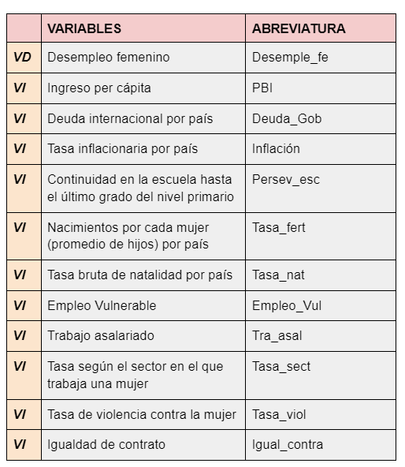

## **C. MODELO DE REGRESIÓN LINEAL MÚLTIPLE**

```r
library(rio)
data0=import("Data_TRABAJO_EST.xlsx")
```

```r
data0$Igual_contrat=as.factor(data0$Igual_contrat)
data0$Igual_contrat=factor(data0$Igual_contrat,
                          levels = levels(data0$Igual_contrat),
                          labels = c("No","Si"),
                          ordered = F)
table(data0$Igual_contrat)
```

```
##
##  No  Si
## 110  96
```

#### TRABAJO ASALARIADO, TASA DE NATALIDAD Y PBI

```r
modelo1<-lm(Desemple_fe~ Tra_asal + Tasa_nat + PBI, data0)
summary(modelo1)
```

```
##
## Call:
## lm(formula = Desemple_fe ~ Tra_asal + Tasa_nat + PBI, data = data0)
##
## Residuals:
##      Min       1Q   Median       3Q      Max
## -11.9920  -3.2308  -0.8108   2.1798  22.6906
##
## Coefficients:
##               Estimate Std. Error t value Pr(>|t|)
## (Intercept) -9.387e+00  3.208e+00  -2.926  0.00403 **
## Tra_asal     1.758e-01  3.094e-02   5.683 7.83e-08 ***
## Tasa_nat     5.007e-01  8.992e-02   5.568 1.34e-07 ***
## PBI         -1.241e-04  2.593e-05  -4.785 4.42e-06 ***
## ---
## Signif. codes:  0 '***' 0.001 '**' 0.01 '*' 0.05 '.' 0.1 ' ' 1
##
## Residual standard error: 5.32 on 135 degrees of freedom
##   (127 observations deleted due to missingness)
## Multiple R-squared:  0.2988, Adjusted R-squared:  0.2832
## F-statistic: 19.18 on 3 and 135 DF,  p-value: 2.036e-10
```

#### **PBI Y EMPLEO VULNERABLE**

```r
modelo2<-lm(Desemple_fe~ PBI + Empleo_Vul, data0)
summary(modelo2)
```

```
##
## Call:
## lm(formula = Desemple_fe ~ PBI + Empleo_Vul, data = data0)
##
## Residuals:
##    Min     1Q Median     3Q    Max
## -9.878 -3.649 -1.111  1.740 30.245
##
## Coefficients:
##               Estimate Std. Error t value Pr(>|t|)
## (Intercept) 12.6986671  1.2554074  10.115  < 2e-16 ***
## PBI         -0.0001344  0.0000284  -4.732  5.5e-06 ***
## Empleo_Vul  -0.0631510  0.0248926  -2.537   0.0123 *
## ---
## Signif. codes:  0 '***' 0.001 '**' 0.01 '*' 0.05 '.' 0.1 ' ' 1
##
## Residual standard error: 5.861 on 136 degrees of freedom
##   (127 observations deleted due to missingness)
## Multiple R-squared:  0.1426, Adjusted R-squared:  0.1299
## F-statistic: 11.31 on 2 and 136 DF,  p-value: 2.87e-05
```

#### **PBI, EMPLEO VULNERABLE E INFLACIÓN**

```r
modelo3<-lm(Desemple_fe~ PBI + Empleo_Vul + Inflación, data0)
summary(modelo3)
```

```
##
## Call:
## lm(formula = Desemple_fe ~ PBI + Empleo_Vul + Inflación, data = data0)
##
## Residuals:
##      Min       1Q   Median       3Q      Max
## -10.0514  -3.5928  -0.9017   1.6599  30.1581
##
## Coefficients:
##               Estimate Std. Error t value Pr(>|t|)
## (Intercept) 13.1705245  1.2440678  10.587  < 2e-16 ***
## PBI         -0.0001419  0.0000279  -5.086 1.23e-06 ***
## Empleo_Vul  -0.0817654  0.0254288  -3.215  0.00164 **
## Inflación    0.0089679  0.0228799   0.392  0.69572
## ---
## Signif. codes:  0 '***' 0.001 '**' 0.01 '*' 0.05 '.' 0.1 ' ' 1
##
## Residual standard error: 5.722 on 132 degrees of freedom
##   (130 observations deleted due to missingness)
## Multiple R-squared:  0.1644, Adjusted R-squared:  0.1454
## F-statistic: 8.657 on 3 and 132 DF,  p-value: 2.754e-05
```

#### **Comparación de modelos**

```r
library(stargazer)
stargazer(modelo1,modelo2, modelo3, type ="text")
```

```
##
## ==========================================================================================
##                                              Dependent variable:
##                     ----------------------------------------------------------------------
##                                                  Desemple_fe
##                               (1)                     (2)                    (3)
## ------------------------------------------------------------------------------------------
## Tra_asal                   0.176***
##                             (0.031)
##
## Tasa_nat                   0.501***
##                             (0.090)
##
## PBI                       -0.0001***              -0.0001***              -0.0001***
##                            (0.00003)               (0.00003)              (0.00003)
##
## Empleo_Vul                                         -0.063**               -0.082***
##                                                     (0.025)                (0.025)
##
## Inflación                                                                   0.009
##                                                                            (0.023)
##
## Constant                   -9.387***               12.699***              13.171***
##                             (3.208)                 (1.255)                (1.244)
##
## ------------------------------------------------------------------------------------------
## Observations                  139                     139                    136
## R2                           0.299                   0.143                  0.164
## Adjusted R2                  0.283                   0.130                  0.145
## Residual Std. Error    5.320 (df = 135)        5.861 (df = 136)        5.722 (df = 132)
## F Statistic         19.176*** (df = 3; 135) 11.306*** (df = 2; 136) 8.657*** (df = 3; 132)
## ==========================================================================================
## Note:                                                          *p<0.1; **p<0.05; ***p<0.01
```

```r
library(modelsummary)
models = list(modelo1,modelo2,modelo3)
modelsummary(models, title = "Regresion: modelo 1, 2 y 3",
             stars = TRUE,
             output = "kableExtra")
```

Regresion: modelo 1, 2 y 3

|  | (1) | (2) | (3) |
| --- | --- | --- | --- |
| (Intercept) | -9.387** | 12.699*** | 13.171*** |
|  | (3.208) | (1.255) | (1.244) |
| Tra_asal | 0.176*** |  |  |
|  | (0.031) |  |  |
| Tasa_nat | 0.501*** |  |  |
|  | (0.090) |  |  |
| PBI | 0.000*** | 0.000*** | 0.000*** |
|  | (0.000) | (0.000) | (0.000) |
| Empleo_Vul |  | -0.063* | -0.082** |
|  |  | (0.025) | (0.025) |
| Inflación |  |  | 0.009 |
|  |  |  | (0.023) |
| Num.Obs. | 139 | 139 | 136 |
| R2 | 0.299 | 0.143 | 0.164 |
| R2 Adj. | 0.283 | 0.130 | 0.145 |
| AIC | 865.1 | 891.0 | 866.4 |
| BIC | 879.7 | 902.8 | 880.9 |
| Log.Lik. | -427.530 | -441.510 | -428.177 |
| F |  |  | 8.657 |
| RMSE | 5.24 | 5.80 | 5.64 |

+ p < 0.1, * p < 0.05, ** p < 0.01, *** p < 0.001

## **DIAGNÓSTICOS DE LA REGRESIÓN:**

#### **1. LINEALIDAD**

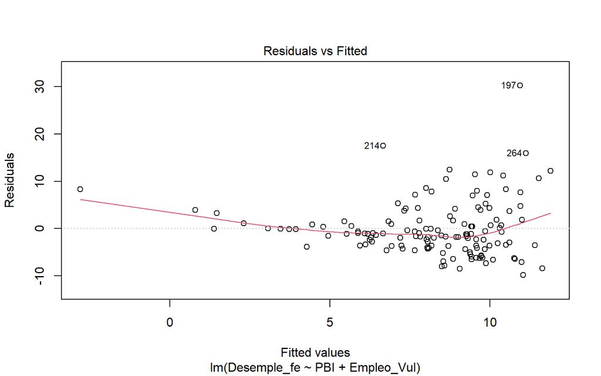

```r
plot(modelo2,1) #Se espera que la línea roja tienda a la horizontal
```

```r
mean(modelo2$residuals)
```

```
## [1] -2.42387e-16
```

#### **2. HOMOCEDASTICIDAD**

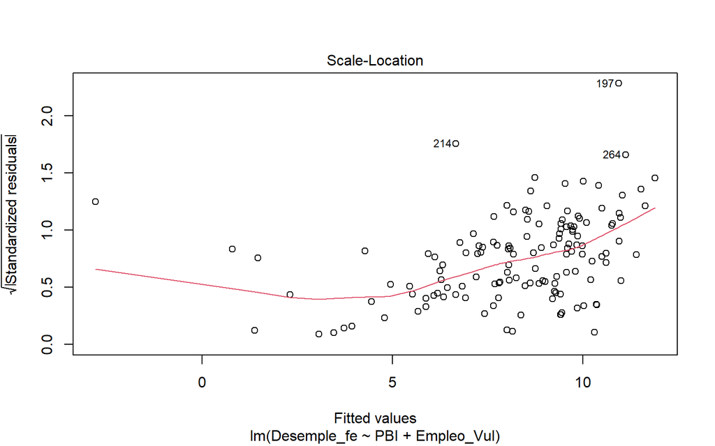

```r
plot(modelo2,3) # Se espera que la línea roja debe tender a horizontal.
```

```r
library(lmtest)
bptest(modelo2)
```

```
##
##  studentized Breusch-Pagan test
##
## data:  modelo2
## BP = 5.8242, df = 2, p-value = 0.05436
```

##### **Nota:** El modelo cumple con el requisito de homocedásticidad, pues se observa que el p-value es mayor a 0.05.

#### **3. NORMALIDAD DE RESIDUOS**

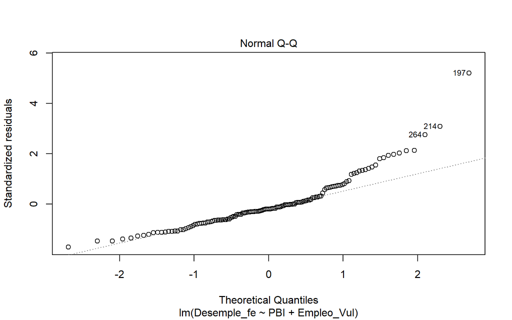

```r
# puntos cerca a la diagonal
plot(modelo2, 2)
```

##### **Test de shapiro**

```r
shapiro.test(modelo2$residuals)
```

```
##
##  Shapiro-Wilk normality test
##
## data:  modelo2$residuals
## W = 0.88818, p-value = 8.191e-09
```

#### **4. NO MULTICOLINELIDAD**

```r
library(DescTools)
VIF(modelo2)
```

```
##        PBI Empleo_Vul
##   1.605861   1.605861
```

#### **5. VALORES INFLUYENTES**

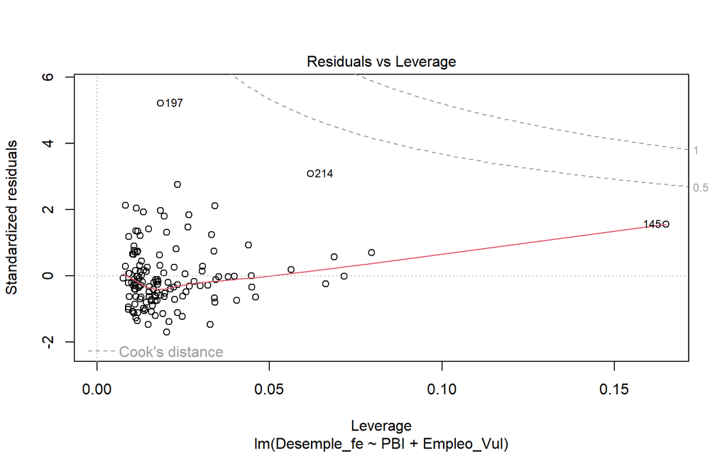

```r
plot(modelo2, 5)
```

```r
checModelo2=as.data.frame(influence.measures(modelo2)$is.inf)
checModelo2[checModelo2$cook.d & checModelo2$hat,] #visualizamos valores
```

```
## [1] dfb.1_   dfb.PBI  dfb.Em_V dffit    cov.r    cook.d   hat
## <0 rows> (or 0-length row.names)
```

##### **NOTA:** Tanto en el gráfico como en la data frame se observa que no hay valores influyentes.

## **CONCLUSIÓN**

Finalmente, podemos decir que el Modelo 2 cumple con 3 de los 5 requisitos de diagnostico.

Interpretación del modelo elegido: Modelo 2

El modelo elegido es el número 2 y para probar nuestra hipótesis debemos apreciar que el efecto que tiene la “Tasa de empleo vulnerable” es significativo con respecto a 0.1, ya que la magnitud con la que se indica a este es de -0.063 el cual indica cuánto varía el desempleo de las mujeres en promedio cuando la tasa de empleo vulnerable aumenta en una unidad, esto siendo controlado por el PBI. Ahora si bien se observa un efecto significativo este es inverso, ya que el coeficiente calculado resulta ser negativo.

Hay casos particulares, que tienen la capacidad de trastocar lo que el modelo representa. A veces detectandose y suprimiéndolos, podemos ver un mejor modelo. Es necesario enfatizar que no todo valor atípico es influyente. Si queremos comprender mejor los posibles casos influyentes, le prestamos atención al índice de Cook y a los valores predecidos (los hat values). Es por ello que, tanto en el caso del gráfico como el data frame, vemos que en el presente caso no hay ninguna fila que afecte los cálculos de la regresión (sin él habría otro resultado).

## D. ANÁLISIS FACTORIAL EXPLORATORIO

```r
library(rio)
data=import("Data_TRABAJO_EST (1).xlsx")
```

```r
data$Desemple_fe=as.numeric(data$Desemple_fe)
```

```r
data = data[complete.cases(data),]
```

### Subseteo de la data:

```r
dontselect=c("Country Name","Country Code" )
select=setdiff(names(data),dontselect)
theData=data[,select]
```

### Calculo de matriz de correlación:

```r
library(polycor)
corMatrix=polycor::hetcor(theData)$correlations
```

### Exploración de correlaciones:

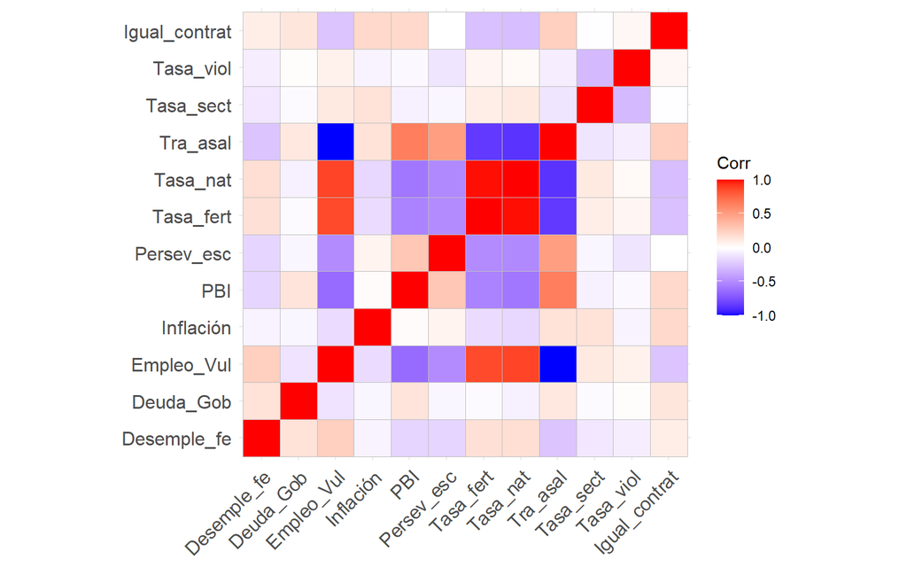

```r
library(ggcorrplot)
ggcorrplot(corMatrix)
```

#### Nota:

Se observa poca esperanza de una analisis factorial.

### Verificación de si los datos permiten factorizar:

```r
library(psych)
psych::KMO(corMatrix)
```

```
## Kaiser-Meyer-Olkin factor adequacy
## Call: psych::KMO(r = corMatrix)
## Overall MSA =  0.74
## MSA for each item =
##   Desemple_fe     Deuda_Gob    Empleo_Vul     Inflación           PBI
##          0.61          0.35          0.75          0.53          0.88
##    Persev_esc     Tasa_fert      Tasa_nat      Tra_asal     Tasa_sect
##          0.95          0.72          0.74          0.75          0.46
##     Tasa_viol Igual_contrat
##          0.35          0.80
```

#### PRUEBA DE M. IDENTIDAD:

```r
cortest.bartlett(corMatrix,n=nrow(theData))$p.value>0.05
```

```
## [1] FALSE
```

#### PRUEBA M.SINGULAR:

```r
library(matrixcalc)

is.singular.matrix(corMatrix)
```

```
## [1] FALSE
```

```r
fa.parallel(theData, fa = 'fa',correct = T,plot = F)
```

```
## Parallel analysis suggests that the number of factors =  1  and the number of components =  NA
```

##### Nota: Probablemente el modelo está teniendo problemas para factorizas algunas de las variables. Sin embargo, nos muestar que se puede factorizar en un factor.

```r
library(GPArotation)
resfa <- fa(theData,
            nfactors = 1,
            cor = 'mixed',
            rotate = "varimax",
            fm="minres")
print(resfa$loadings)
```

```
##
## Loadings:
##               MR1
## Desemple_fe    0.211
## Deuda_Gob
## Empleo_Vul     0.974
## Inflación     -0.159
## PBI           -0.635
## Persev_esc    -0.506
## Tasa_fert      0.922
## Tasa_nat       0.957
## Tra_asal      -0.967
## Tasa_sect
## Tasa_viol
## Igual_contrat -0.329
##
##                  MR1
## SS loadings    4.507
## Proportion Var 0.376
```

```r
print(resfa$loadings,cutoff = 0.5)
```

```
##
## Loadings:
##               MR1
## Desemple_fe
## Deuda_Gob
## Empleo_Vul     0.974
## Inflación
## PBI           -0.635
## Persev_esc    -0.506
## Tasa_fert      0.922
## Tasa_nat       0.957
## Tra_asal      -0.967
## Tasa_sect
## Tasa_viol
## Igual_contrat
##
##                  MR1
## SS loadings    4.507
## Proportion Var 0.376
```

#### Resultado visual:

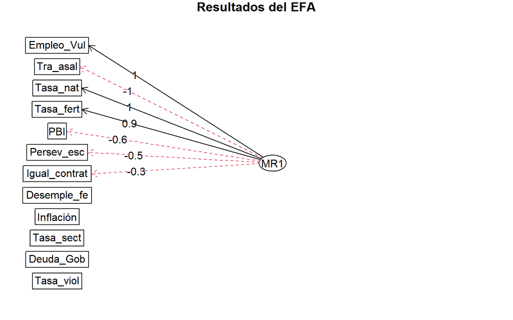

```r
fa.diagram(resfa,main = "Resultados del EFA")
```

#### Evaluando resultados:

```r
sort(resfa$communality)
```

```
##     Tasa_viol     Deuda_Gob     Tasa_sect     Inflación   Desemple_fe
##   0.002688875   0.007738599   0.007834770   0.025389743   0.044369926
## Igual_contrat    Persev_esc           PBI     Tasa_fert      Tasa_nat
##   0.108350926   0.256479673   0.403697465   0.850902307   0.915498248
##      Tra_asal    Empleo_Vul
##   0.935994611   0.948102800
```

##### Nota: Se muestra, como también lo constata el gráfico, que algunas variables aportan a la factorización. No obstante, prevalece las que no aportan.

```r
sort(resfa$complexity)
```

```
##     Tasa_fert      Tasa_nat   Desemple_fe    Empleo_Vul     Inflación
##             1             1             1             1             1
##           PBI    Persev_esc      Tra_asal     Tasa_sect Igual_contrat
##             1             1             1             1             1
##     Deuda_Gob     Tasa_viol
##             1             1
```

##### Nota: Con esta prueba se verifica que las variables no contribuyen a más de un factor.

```r
library(magrittr)
as.data.frame(resfa$scores)%>%head()
```

```
##           MR1
## 2   1.6169774
## 3   1.5800931
## 7  -0.8754651
## 12 -0.9672849
## 13 -0.1681938
## 15 -1.0534339
```

## Conclusión:

Las distintas pruebas y el anális factorial exploratorio nos demuestran que los valores encontrados en nuestra base de datos son difíciles de sientetizar en un número determinado de factores.

En resumen, el análisis factorial exploratorio realizado no ha arrojado resultados significativos o concluyentes. A pesar de nuestros esfuerzos por identificar factores claros y patrones en los datos, no se encontraron estructuras discernibles que pudieran ser interpretadas de manera significativa. Esta falta de resultados puede atribuirse a diversas limitaciones y factores que podrían haber influido en el análisis. Es posible que las limitaciones en la calidad o la selección de los datos hayan afectado la capacidad de identificar factores relevantes. Además, el tamaño de la muestra puede haber sido insuficiente para capturar las relaciones complejas y sutiles presentes en los datos. También es posible que las variables seleccionadas no hayan sido las más adecuadas para el análisis, lo que podría haber afectado la identificación de estructuras latentes. Este análisis nos ha proporcionado lecciones valiosas sobre las limitaciones metodológicas y los desafíos asociados con el estudio del fenómeno en cuestión. Reflexionando sobre estos resultados, es evidente la importancia de una cuidadosa selección de variables, una muestra representativa y técnicas de análisis adecuadas para obtener resultados más sólidos en investigaciones futuras.

En conclusión, a pesar de no haber obtenido resultados concluyentes en este análisis factorial exploratorio, los hallazgos negativos nos brindan valiosas enseñanzas sobre las limitaciones del estudio y nos guían hacia posibles mejoras en futuras investigaciones.Por lo tanto, nuestras variables no están listas para el análisis factoiral completo, impidiendo realizar el siguiente pasó a seguir el cuál es el analisi factorial confirmatorio.